# OPTIMASI PORTOFOLIO BERBASIS MODEL MARKOWITZ MENGGUNAKAN METODE VARIATIONAL QUANTUM EIGENSOLVER

## Pergerakan Harga Saham ($N=4$)

Kombinasi saham BBCA, ADRO, TLKM, dan SMGR (2021-2023) dievaluasi dengan mekanisme *rebalancing* bulanan.

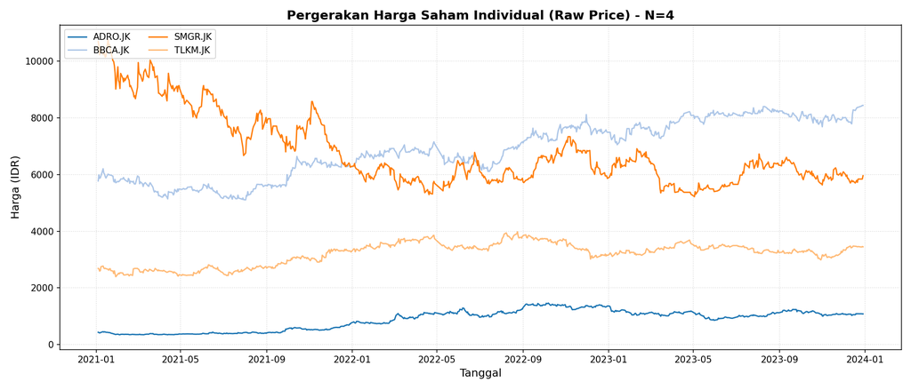

## Perbandingan Pertumbuhan Modal Benchmark ($N=2$)

Perbandingan performa *backtesting* antara Portofolio Nash murni (tanpa VQE) dan optimasi portofolio klasik SLSQP untuk 2 aset.

**Portofolio Nash Murni**

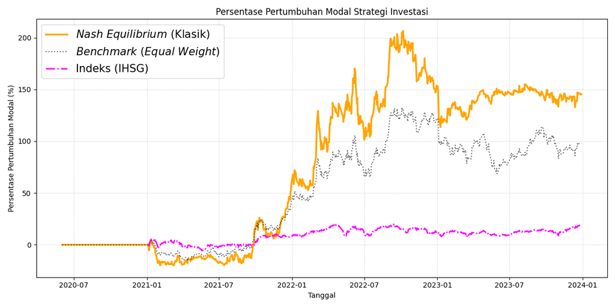

**Optimasi Klasik (SLSQP)**

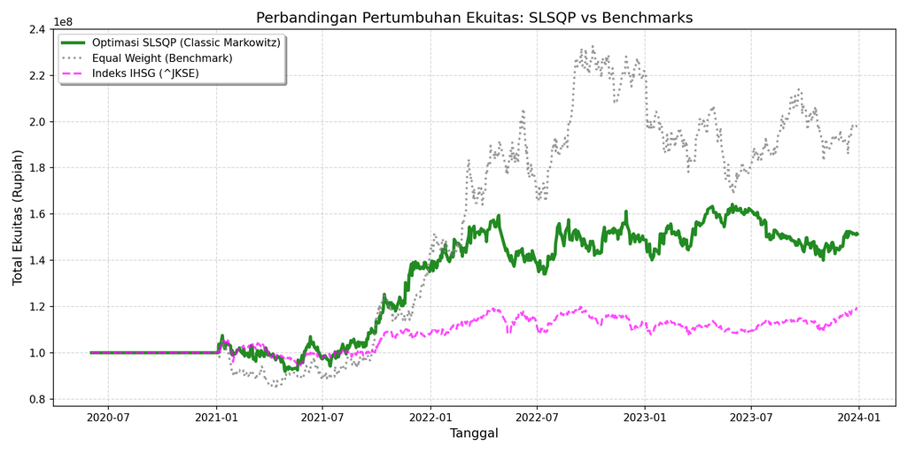

## Perbandingan Pertumbuhan Modal Benchmark ($N=4$)

Perbandingan performa *backtesting* antara Portofolio Nash murni (tanpa VQE) dan optimasi portofolio klasik SLSQP untuk 4 aset.

**Portofolio Nash Murni**

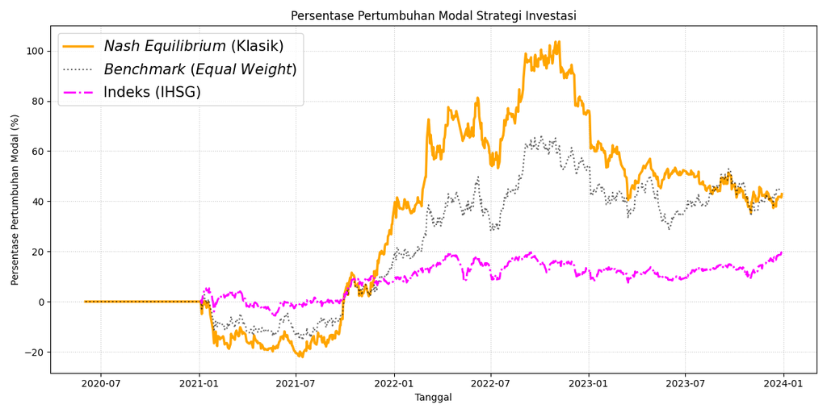

**Optimasi Klasik (SLSQP)**

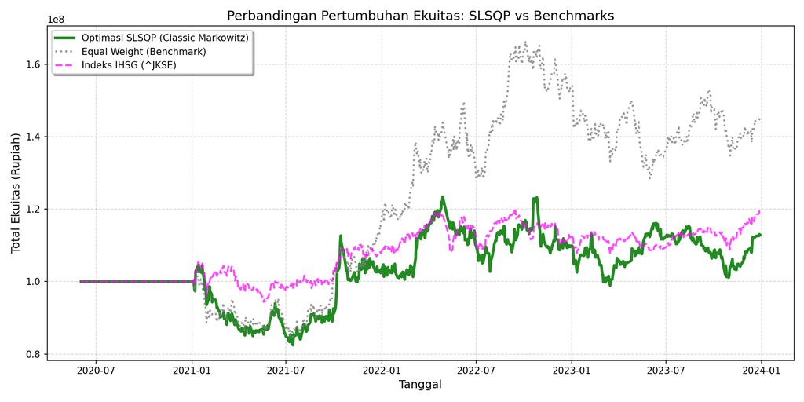

## Perbandingan Pertumbuhan Modal ($N=2$)

Perbandingan antara VQE Murni (Tanpa GT) dan Algoritma GT-VQE (Hibrida) untuk 2 aset.

**VQE Murni (Tanpa GT)**

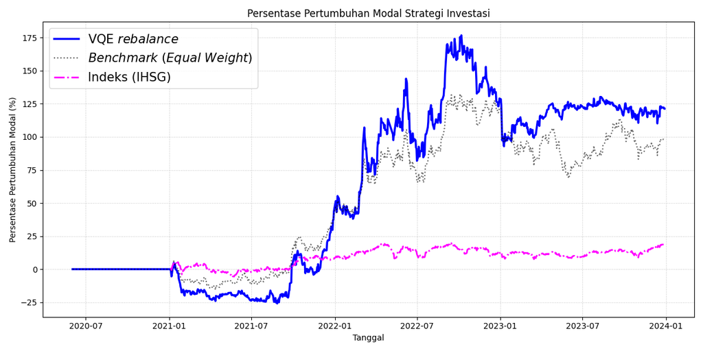

**GT-VQE (Hibrida)**

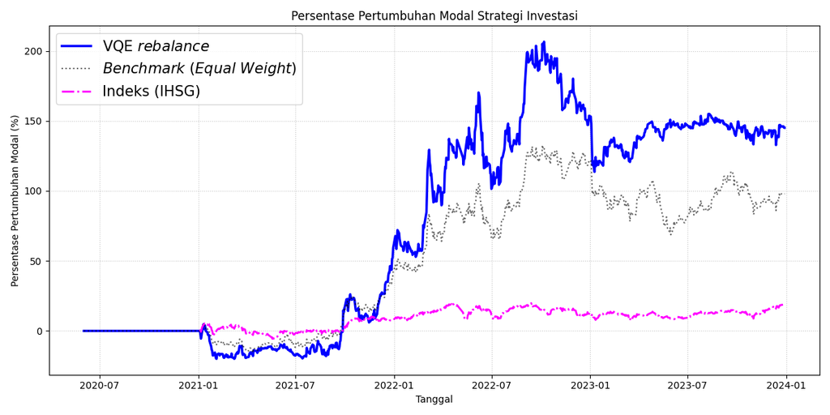

## Perbandingan Pertumbuhan Modal ($N=4$)

Perbandingan antara VQE Murni (Tanpa GT) dan Algoritma GT-VQE (Hibrida) untuk 4 aset.

**VQE Murni (Tanpa GT)**

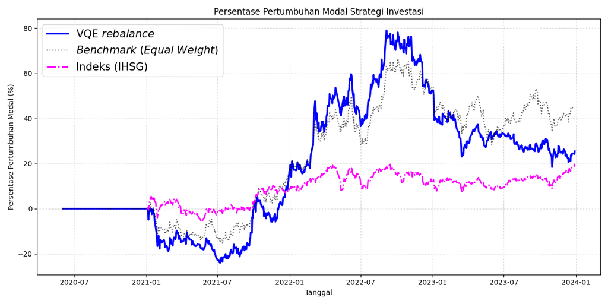

**GT-VQE (Hibrida)**

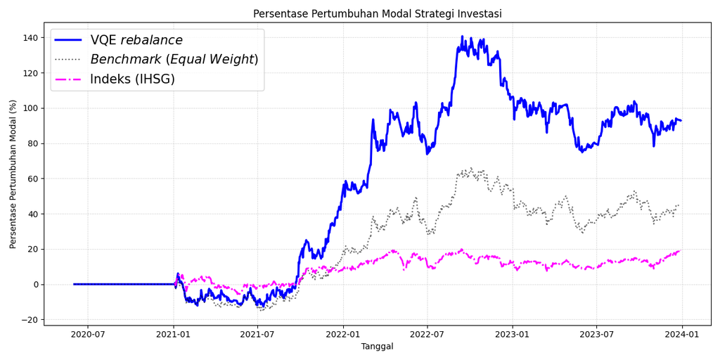

## Dinamika Adaptasi Kedalaman Sirkuit ($N=2$)

**VQE Murni ($N=2$)**

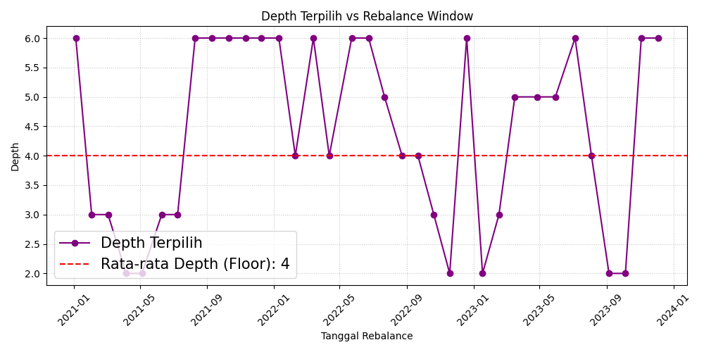

**GT-VQE Hibrida ($N=2$)**

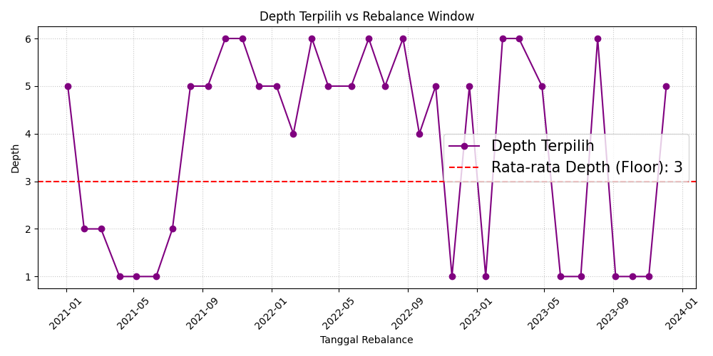

## Dinamika Adaptasi Kedalaman Sirkuit ($N=4$)

**VQE Murni ($N=4$)**

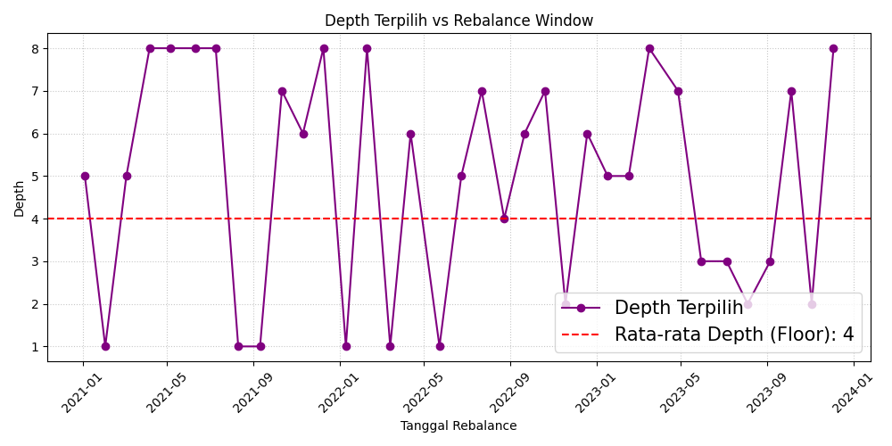

**GT-VQE Hibrida ($N=4$)**

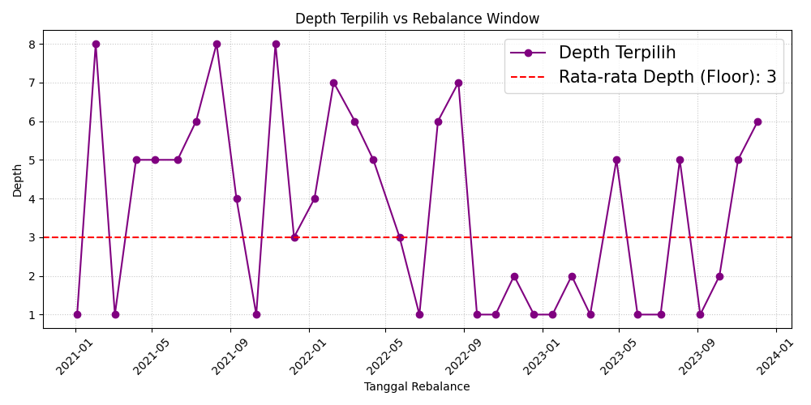

## Ringkasan Performa Simulasi Finansial

Tabel perbandingan *backtesting* strategi Kuantum, SLSQP, dan *Equal Weight* untuk Sistem $N=2$ dan $N=4$.

[output not shown]

**Catatan:** GT-VQE mendominasi performa pengembalian maupun rasio *Sharpe* karena inisialisasi *Nash Equilibrium* berhasil mengeksploitasi informasi struktural pasar.

## Kesimpulan

### Formulasi EPG

Formulasi model Markowitz ke dalam kerangka *Exact Potential Game* (EPG) telah berhasil memetakan utilitas ekonomi menjadi sistem Hamiltonian fisis secara akurat. Penggunaan *log return* efektif menjaga simetri interaksi risiko tanpa distorsi, sementara implementasi suku penalti mencegah sirkuit kuantum terjebak pada status portofolio yang melanggar diversifikasi.

➜

### Warm-Start Nash

Penerapan *Nash Equilibrium* sebagai *warm-start* terbukti meningkatkan efisiensi algoritma VQE. Solusi *Nash* yang diinjeksikan ke awal sirkuit membantu optimasi lolos dari area *barren plateaus* dan memicu keruntuhan entropi *Von Neumann*, sehingga memungkinkan pencapaian *ground state* pada kedalaman sirkuit dengan rata-rata yang lebih dangkal.

➜

## Saran Pengembangan

### Noise Sirkuit

Mempertimbangkan parameter *noise* sirkuit, seperti dekoherensi qubit dan *gate fidelity* dalam mengeksekusi algoritma ini agar divalidasi dan diaplikasikan pada infrastruktur perangkat keras kuantum sesungguhnya.

➜

### Variasi Ansatz

Menggunakan variasi struktur *ansatz* lain (seperti *Qubit-Efficient* atau *Variational Quantum Circuit*) serta membandingkan performa berbagai algoritma optimasi klasik lainnya untuk menemukan kombinasi hibrida dengan laju konvergensi paling efisien.

➜

### Black Swan

Menggunakan rentang periode data historis yang lebih panjang dan melakukan pengujian pada periode fenomena *Black Swan* atau krisis ekonomi untuk mengevaluasi agilitas dan reliabilitas algoritma dalam mempertahankan stabilitas portofolio di pasar ekstrem.

# Terima Kasih

# Lampiran

## Lampiran: Grafik Simulasi GT-VQE ($N=4$)

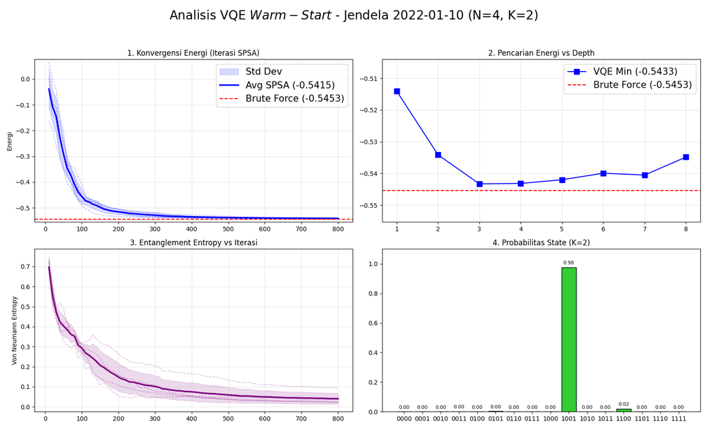

## Lampiran: Grafik Simulasi VQE Murni ($N=4$)

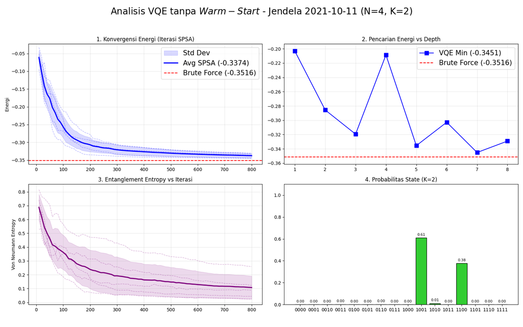

[figure not shown]

"The Beauty of Mind"  
"The Art of Thinking"

www.its.ac.id

INSTITUT TEKNOLOGI SEPULUH NOPEMBER, Surabaya - Indonesia